# Risk Factor Analysis

## Outcome Variable

**Outcome Variable:** ever_co

## Predictor Variables

**Intervention Variable:** exclfeed36

**Adjustment Set:**

unadjusted

## Stratifying Variables

The analysis was stratified on these variable(s):

- agecat
- studyid
- country

## Data Summary

| agecat | studyid | country | exclfeed36 | ever_co | n_cell | n |
| --- | --- | --- | --- | --- | --- | --- |
| 0-24 months | CMC-V-BCS-2002 | INDIA | 1 | 0 | 8 | 9 |
| 0-24 months | CMC-V-BCS-2002 | INDIA | 1 | 1 | 1 | 9 |
| 0-24 months | CMC-V-BCS-2002 | INDIA | 0 | 0 | 0 | 9 |
| 0-24 months | CMC-V-BCS-2002 | INDIA | 0 | 1 | 0 | 9 |
| 0-24 months | EE | PAKISTAN | 1 | 0 | 3 | 9 |
| 0-24 months | EE | PAKISTAN | 1 | 1 | 1 | 9 |
| 0-24 months | EE | PAKISTAN | 0 | 0 | 5 | 9 |
| 0-24 months | EE | PAKISTAN | 0 | 1 | 0 | 9 |
| 0-24 months | GMS-Nepal | NEPAL | 1 | 0 | 286 | 528 |
| 0-24 months | GMS-Nepal | NEPAL | 1 | 1 | 137 | 528 |
| 0-24 months | GMS-Nepal | NEPAL | 0 | 0 | 64 | 528 |
| 0-24 months | GMS-Nepal | NEPAL | 0 | 1 | 41 | 528 |
| 0-24 months | IRC | INDIA | 1 | 0 | 0 | 4 |
| 0-24 months | IRC | INDIA | 1 | 1 | 0 | 4 |
| 0-24 months | IRC | INDIA | 0 | 0 | 3 | 4 |
| 0-24 months | IRC | INDIA | 0 | 1 | 1 | 4 |
| 0-24 months | JiVitA-3 | BANGLADESH | 1 | 0 | 9001 | 12748 |
| 0-24 months | JiVitA-3 | BANGLADESH | 1 | 1 | 922 | 12748 |
| 0-24 months | JiVitA-3 | BANGLADESH | 0 | 0 | 2543 | 12748 |
| 0-24 months | JiVitA-3 | BANGLADESH | 0 | 1 | 282 | 12748 |
| 0-24 months | JiVitA-4 | BANGLADESH | 1 | 0 | 3010 | 4589 |
| 0-24 months | JiVitA-4 | BANGLADESH | 1 | 1 | 532 | 4589 |
| 0-24 months | JiVitA-4 | BANGLADESH | 0 | 0 | 834 | 4589 |
| 0-24 months | JiVitA-4 | BANGLADESH | 0 | 1 | 213 | 4589 |
| 0-24 months | Keneba | GAMBIA | 1 | 0 | 538 | 1983 |
| 0-24 months | Keneba | GAMBIA | 1 | 1 | 87 | 1983 |
| 0-24 months | Keneba | GAMBIA | 0 | 0 | 1103 | 1983 |
| 0-24 months | Keneba | GAMBIA | 0 | 1 | 255 | 1983 |
| 0-24 months | LCNI-5 | MALAWI | 1 | 0 | 44 | 272 |
| 0-24 months | LCNI-5 | MALAWI | 1 | 1 | 3 | 272 |

[output cut: 174 more lines]

The following strata were considered:

- agecat: 0-24 months, studyid: CMC-V-BCS-2002, country: INDIA
- agecat: 0-24 months, studyid: EE, country: PAKISTAN
- agecat: 0-24 months, studyid: GMS-Nepal, country: NEPAL
- agecat: 0-24 months, studyid: IRC, country: INDIA
- agecat: 0-24 months, studyid: JiVitA-3, country: BANGLADESH
- agecat: 0-24 months, studyid: JiVitA-4, country: BANGLADESH
- agecat: 0-24 months, studyid: Keneba, country: GAMBIA
- agecat: 0-24 months, studyid: LCNI-5, country: MALAWI
- agecat: 0-24 months, studyid: MAL-ED, country: BANGLADESH
- agecat: 0-24 months, studyid: MAL-ED, country: BRAZIL
- agecat: 0-24 months, studyid: MAL-ED, country: INDIA
- agecat: 0-24 months, studyid: MAL-ED, country: NEPAL
- agecat: 0-24 months, studyid: MAL-ED, country: PERU
- agecat: 0-24 months, studyid: MAL-ED, country: SOUTH AFRICA
- agecat: 0-24 months, studyid: MAL-ED, country: TANZANIA, UNITED REPUBLIC OF
- agecat: 0-24 months, studyid: PROVIDE, country: BANGLADESH
- agecat: 0-24 months, studyid: SAS-FoodSuppl, country: INDIA
- agecat: 0-6 months, studyid: CMC-V-BCS-2002, country: INDIA
- agecat: 0-6 months, studyid: EE, country: PAKISTAN
- agecat: 0-6 months, studyid: GMS-Nepal, country: NEPAL
- agecat: 0-6 months, studyid: IRC, country: INDIA
- agecat: 0-6 months, studyid: JiVitA-3, country: BANGLADESH
- agecat: 0-6 months, studyid: JiVitA-4, country: BANGLADESH
- agecat: 0-6 months, studyid: Keneba, country: GAMBIA
- agecat: 0-6 months, studyid: LCNI-5, country: MALAWI
- agecat: 0-6 months, studyid: MAL-ED, country: BANGLADESH
- agecat: 0-6 months, studyid: MAL-ED, country: BRAZIL
- agecat: 0-6 months, studyid: MAL-ED, country: INDIA
- agecat: 0-6 months, studyid: MAL-ED, country: NEPAL
- agecat: 0-6 months, studyid: MAL-ED, country: PERU
- agecat: 0-6 months, studyid: MAL-ED, country: SOUTH AFRICA
- agecat: 0-6 months, studyid: MAL-ED, country: TANZANIA, UNITED REPUBLIC OF
- agecat: 0-6 months, studyid: PROVIDE, country: BANGLADESH
- agecat: 0-6 months, studyid: SAS-FoodSuppl, country: INDIA
- agecat: 6-24 months, studyid: CMC-V-BCS-2002, country: INDIA
- agecat: 6-24 months, studyid: EE, country: PAKISTAN
- agecat: 6-24 months, studyid: GMS-Nepal, country: NEPAL
- agecat: 6-24 months, studyid: IRC, country: INDIA
- agecat: 6-24 months, studyid: JiVitA-3, country: BANGLADESH
- agecat: 6-24 months, studyid: JiVitA-4, country: BANGLADESH
- agecat: 6-24 months, studyid: Keneba, country: GAMBIA
- agecat: 6-24 months, studyid: LCNI-5, country: MALAWI
- agecat: 6-24 months, studyid: MAL-ED, country: BANGLADESH
- agecat: 6-24 months, studyid: MAL-ED, country: BRAZIL
- agecat: 6-24 months, studyid: MAL-ED, country: INDIA
- agecat: 6-24 months, studyid: MAL-ED, country: NEPAL
- agecat: 6-24 months, studyid: MAL-ED, country: PERU
- agecat: 6-24 months, studyid: MAL-ED, country: SOUTH AFRICA
- agecat: 6-24 months, studyid: MAL-ED, country: TANZANIA, UNITED REPUBLIC OF
- agecat: 6-24 months, studyid: PROVIDE, country: BANGLADESH
- agecat: 6-24 months, studyid: SAS-FoodSuppl, country: INDIA

### Dropped Strata

Some strata were dropped due to rare outcomes:

- agecat: 0-24 months, studyid: CMC-V-BCS-2002, country: INDIA
- agecat: 0-24 months, studyid: EE, country: PAKISTAN
- agecat: 0-24 months, studyid: IRC, country: INDIA
- agecat: 0-24 months, studyid: LCNI-5, country: MALAWI
- agecat: 0-24 months, studyid: MAL-ED, country: BANGLADESH
- agecat: 0-24 months, studyid: MAL-ED, country: BRAZIL
- agecat: 0-24 months, studyid: MAL-ED, country: INDIA
- agecat: 0-24 months, studyid: MAL-ED, country: NEPAL
- agecat: 0-24 months, studyid: MAL-ED, country: PERU
- agecat: 0-24 months, studyid: MAL-ED, country: SOUTH AFRICA
- agecat: 0-24 months, studyid: MAL-ED, country: TANZANIA, UNITED REPUBLIC OF
- agecat: 0-24 months, studyid: SAS-FoodSuppl, country: INDIA
- agecat: 0-6 months, studyid: CMC-V-BCS-2002, country: INDIA
- agecat: 0-6 months, studyid: EE, country: PAKISTAN
- agecat: 0-6 months, studyid: IRC, country: INDIA
- agecat: 0-6 months, studyid: LCNI-5, country: MALAWI
- agecat: 0-6 months, studyid: MAL-ED, country: BANGLADESH
- agecat: 0-6 months, studyid: MAL-ED, country: BRAZIL
- agecat: 0-6 months, studyid: MAL-ED, country: INDIA
- agecat: 0-6 months, studyid: MAL-ED, country: NEPAL
- agecat: 0-6 months, studyid: MAL-ED, country: PERU
- agecat: 0-6 months, studyid: MAL-ED, country: SOUTH AFRICA
- agecat: 0-6 months, studyid: MAL-ED, country: TANZANIA, UNITED REPUBLIC OF
- agecat: 0-6 months, studyid: PROVIDE, country: BANGLADESH
- agecat: 0-6 months, studyid: SAS-FoodSuppl, country: INDIA
- agecat: 6-24 months, studyid: CMC-V-BCS-2002, country: INDIA
- agecat: 6-24 months, studyid: EE, country: PAKISTAN
- agecat: 6-24 months, studyid: IRC, country: INDIA
- agecat: 6-24 months, studyid: LCNI-5, country: MALAWI
- agecat: 6-24 months, studyid: MAL-ED, country: BANGLADESH
- agecat: 6-24 months, studyid: MAL-ED, country: BRAZIL
- agecat: 6-24 months, studyid: MAL-ED, country: INDIA
- agecat: 6-24 months, studyid: MAL-ED, country: NEPAL
- agecat: 6-24 months, studyid: MAL-ED, country: PERU
- agecat: 6-24 months, studyid: MAL-ED, country: SOUTH AFRICA
- agecat: 6-24 months, studyid: MAL-ED, country: TANZANIA, UNITED REPUBLIC OF
- agecat: 6-24 months, studyid: SAS-FoodSuppl, country: INDIA

## Methods Detail

We’re interested in the causal parameters $E[Y_a]$ for all values of $a \in \mathcal{A}$. These parameters represent the mean outcome if, possibly contrary to fact, we intervened to set all units to have $A=a$. Under the randomization and positivity assumptions, these are identified by the statistical parameters $\psi_a=E_W[E_{Y|A,W}(Y|A=a,W)]$. In addition, we’re interested in the mean of $Y$, $E[Y]$ under no intervention (the observed mean). We will estimate these parameters by using SuperLearner to fit the relevant likelihood factors – $E_{Y|A,W}(Y|A=a,W)$ and $p(A=a|W)$, and then updating our likelihood fit using a joint TMLE.

For unadjusted analyses ($W=\{\}$), initial likelihoods were estimated using Lrnr_glm to estimate the simple $E(Y|A)$ and Lrnr_mean to estimate $p(A)$. For adjusted analyses, a small library containing Lrnr_glmnet, Lrnr_xgboost, and Lrnr_mean was used.

Having estimated these parameters, we will then use the delta method to estimate relative risks and attributable risks relative to a prespecified baseline level of $A$.

# Results Detail

## Results Plots

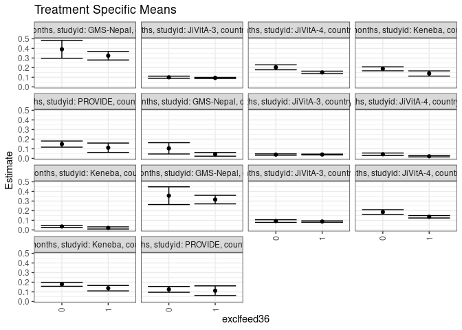

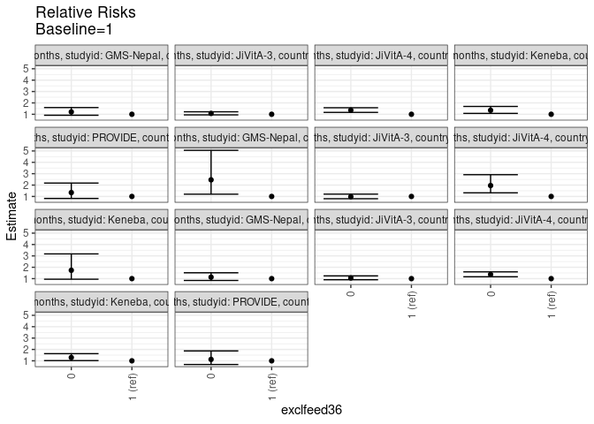

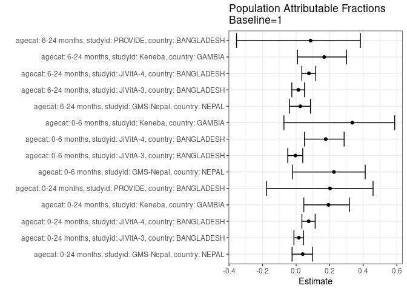

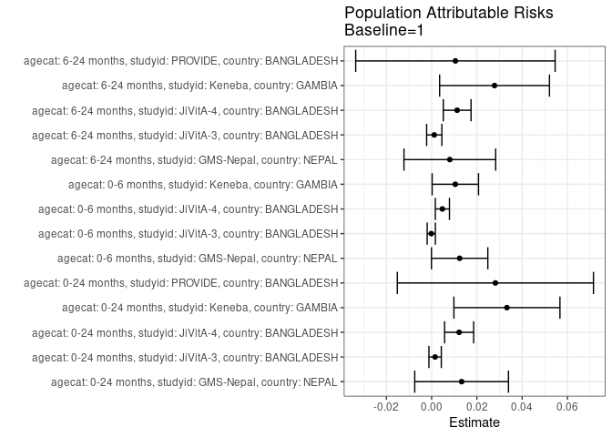

## Results Table

### Parameter: TSM

| agecat | studyid | country | intervention_level | baseline_level | estimate | ci_lower | ci_upper |
| --- | --- | --- | --- | --- | --- | --- | --- |
| 0-24 months | GMS-Nepal | NEPAL | 1 | NA | 0.3238771 | 0.2792403 | 0.3685138 |
| 0-24 months | GMS-Nepal | NEPAL | 0 | NA | 0.3904762 | 0.2970739 | 0.4838785 |
| 0-24 months | JiVitA-3 | BANGLADESH | 1 | NA | 0.0929154 | 0.0867215 | 0.0991094 |
| 0-24 months | JiVitA-3 | BANGLADESH | 0 | NA | 0.0998230 | 0.0887485 | 0.1108975 |
| 0-24 months | JiVitA-4 | BANGLADESH | 1 | NA | 0.1501976 | 0.1369386 | 0.1634567 |
| 0-24 months | JiVitA-4 | BANGLADESH | 0 | NA | 0.2034384 | 0.1777322 | 0.2291446 |
| 0-24 months | Keneba | GAMBIA | 1 | NA | 0.1392000 | 0.1120551 | 0.1663449 |
| 0-24 months | Keneba | GAMBIA | 0 | NA | 0.1877761 | 0.1670000 | 0.2085523 |
| 0-24 months | PROVIDE | BANGLADESH | 1 | NA | 0.1111111 | 0.0626790 | 0.1595432 |
| 0-24 months | PROVIDE | BANGLADESH | 0 | NA | 0.1488470 | 0.1168799 | 0.1808140 |
| 0-6 months | GMS-Nepal | NEPAL | 1 | NA | 0.0425532 | 0.0232995 | 0.0618068 |
| 0-6 months | GMS-Nepal | NEPAL | 0 | NA | 0.1047619 | 0.0461297 | 0.1633941 |
| 0-6 months | JiVitA-3 | BANGLADESH | 1 | NA | 0.0404969 | 0.0362674 | 0.0447263 |
| 0-6 months | JiVitA-3 | BANGLADESH | 0 | NA | 0.0397304 | 0.0326260 | 0.0468348 |
| 0-6 months | JiVitA-4 | BANGLADESH | 1 | NA | 0.0221277 | 0.0161062 | 0.0281491 |
| 0-6 months | JiVitA-4 | BANGLADESH | 0 | NA | 0.0433498 | 0.0305591 | 0.0561404 |
| 0-6 months | Keneba | GAMBIA | 1 | NA | 0.0208000 | 0.0096086 | 0.0319914 |
| 0-6 months | Keneba | GAMBIA | 0 | NA | 0.0360825 | 0.0261610 | 0.0460039 |
| 6-24 months | GMS-Nepal | NEPAL | 1 | NA | 0.3151659 | 0.2707981 | 0.3595336 |
| 6-24 months | GMS-Nepal | NEPAL | 0 | NA | 0.3557692 | 0.2636714 | 0.4478671 |
| 6-24 months | JiVitA-3 | BANGLADESH | 1 | NA | 0.0873600 | 0.0802752 | 0.0944449 |
| 6-24 months | JiVitA-3 | BANGLADESH | 0 | NA | 0.0923913 | 0.0787548 | 0.1060278 |
| 6-24 months | JiVitA-4 | BANGLADESH | 1 | NA | 0.1366337 | 0.1242318 | 0.1490355 |
| 6-24 months | JiVitA-4 | BANGLADESH | 0 | NA | 0.1861804 | 0.1617832 | 0.2105777 |
| 6-24 months | Keneba | GAMBIA | 1 | NA | 0.1381693 | 0.1100542 | 0.1662844 |
| 6-24 months | Keneba | GAMBIA | 0 | NA | 0.1781132 | 0.1575065 | 0.1987199 |
| 6-24 months | PROVIDE | BANGLADESH | 1 | NA | 0.1118421 | 0.0616970 | 0.1619872 |
| 6-24 months | PROVIDE | BANGLADESH | 0 | NA | 0.1258134 | 0.0955152 | 0.1561117 |

### Parameter: E(Y)

| agecat | studyid | country | intervention_level | baseline_level | estimate | ci_lower | ci_upper |
| --- | --- | --- | --- | --- | --- | --- | --- |
| 0-24 months | GMS-Nepal | NEPAL | NA | NA | 0.3371212 | 0.2967611 | 0.3774814 |
| 0-24 months | JiVitA-3 | BANGLADESH | NA | NA | 0.0944462 | 0.0888980 | 0.0999944 |
| 0-24 months | JiVitA-4 | BANGLADESH | NA | NA | 0.1623447 | 0.1503363 | 0.1743531 |
| 0-24 months | Keneba | GAMBIA | NA | NA | 0.1724660 | 0.1558341 | 0.1890978 |
| 0-24 months | PROVIDE | BANGLADESH | NA | NA | 0.1392801 | 0.1124135 | 0.1661468 |
| 0-6 months | GMS-Nepal | NEPAL | NA | NA | 0.0549242 | 0.0354725 | 0.0743760 |
| 0-6 months | JiVitA-3 | BANGLADESH | NA | NA | 0.0403270 | 0.0366289 | 0.0440252 |
| 0-6 months | JiVitA-4 | BANGLADESH | NA | NA | 0.0268722 | 0.0213332 | 0.0324113 |
| 0-6 months | Keneba | GAMBIA | NA | NA | 0.0312658 | 0.0236039 | 0.0389276 |
| 6-24 months | GMS-Nepal | NEPAL | NA | NA | 0.3231939 | 0.2831873 | 0.3632006 |
| 6-24 months | JiVitA-3 | BANGLADESH | NA | NA | 0.0885157 | 0.0819350 | 0.0950963 |
| 6-24 months | JiVitA-4 | BANGLADESH | NA | NA | 0.1479135 | 0.1367519 | 0.1590750 |
| 6-24 months | Keneba | GAMBIA | NA | NA | 0.1659664 | 0.1492505 | 0.1826823 |
| 6-24 months | PROVIDE | BANGLADESH | NA | NA | 0.1223491 | 0.0963874 | 0.1483108 |

### Parameter: RR

| agecat | studyid | country | intervention_level | baseline_level | estimate | ci_lower | ci_upper |
| --- | --- | --- | --- | --- | --- | --- | --- |
| 0-24 months | GMS-Nepal | NEPAL | 1 | 1 | 1.0000000 | 1.0000000 | 1.000000 |
| 0-24 months | GMS-Nepal | NEPAL | 0 | 1 | 1.2056309 | 0.9147894 | 1.588940 |
| 0-24 months | JiVitA-3 | BANGLADESH | 1 | 1 | 1.0000000 | 1.0000000 | 1.000000 |
| 0-24 months | JiVitA-3 | BANGLADESH | 0 | 1 | 1.0743424 | 0.9474567 | 1.218221 |
| 0-24 months | JiVitA-4 | BANGLADESH | 1 | 1 | 1.0000000 | 1.0000000 | 1.000000 |
| 0-24 months | JiVitA-4 | BANGLADESH | 0 | 1 | 1.3544714 | 1.1648336 | 1.574983 |
| 0-24 months | Keneba | GAMBIA | 1 | 1 | 1.0000000 | 1.0000000 | 1.000000 |
| 0-24 months | Keneba | GAMBIA | 0 | 1 | 1.3489665 | 1.0780245 | 1.688005 |
| 0-24 months | PROVIDE | BANGLADESH | 1 | 1 | 1.0000000 | 1.0000000 | 1.000000 |
| 0-24 months | PROVIDE | BANGLADESH | 0 | 1 | 1.3396226 | 0.8240395 | 2.177795 |
| 0-6 months | GMS-Nepal | NEPAL | 1 | 1 | 1.0000000 | 1.0000000 | 1.000000 |
| 0-6 months | GMS-Nepal | NEPAL | 0 | 1 | 2.4619048 | 1.1987106 | 5.056246 |
| 0-6 months | JiVitA-3 | BANGLADESH | 1 | 1 | 1.0000000 | 1.0000000 | 1.000000 |
| 0-6 months | JiVitA-3 | BANGLADESH | 0 | 1 | 0.9810734 | 0.8000788 | 1.203013 |
| 0-6 months | JiVitA-4 | BANGLADESH | 1 | 1 | 1.0000000 | 1.0000000 | 1.000000 |
| 0-6 months | JiVitA-4 | BANGLADESH | 0 | 1 | 1.9590754 | 1.3173110 | 2.913493 |
| 0-6 months | Keneba | GAMBIA | 1 | 1 | 1.0000000 | 1.0000000 | 1.000000 |
| 0-6 months | Keneba | GAMBIA | 0 | 1 | 1.7347343 | 0.9480166 | 3.174315 |
| 6-24 months | GMS-Nepal | NEPAL | 1 | 1 | 1.0000000 | 1.0000000 | 1.000000 |
| 6-24 months | GMS-Nepal | NEPAL | 0 | 1 | 1.1288317 | 0.8407269 | 1.515666 |
| 6-24 months | JiVitA-3 | BANGLADESH | 1 | 1 | 1.0000000 | 1.0000000 | 1.000000 |
| 6-24 months | JiVitA-3 | BANGLADESH | 0 | 1 | 1.0575922 | 0.9008368 | 1.241625 |
| 6-24 months | JiVitA-4 | BANGLADESH | 1 | 1 | 1.0000000 | 1.0000000 | 1.000000 |
| 6-24 months | JiVitA-4 | BANGLADESH | 0 | 1 | 1.3626248 | 1.1637486 | 1.595487 |
| 6-24 months | Keneba | GAMBIA | 1 | 1 | 1.0000000 | 1.0000000 | 1.000000 |
| 6-24 months | Keneba | GAMBIA | 0 | 1 | 1.2890943 | 1.0200648 | 1.629077 |
| 6-24 months | PROVIDE | BANGLADESH | 1 | 1 | 1.0000000 | 1.0000000 | 1.000000 |
| 6-24 months | PROVIDE | BANGLADESH | 0 | 1 | 1.1249203 | 0.6762279 | 1.871330 |

### Parameter: PAR

| agecat | studyid | country | intervention_level | baseline_level | estimate | ci_lower | ci_upper |
| --- | --- | --- | --- | --- | --- | --- | --- |
| 0-24 months | GMS-Nepal | NEPAL | 1 | NA | 0.0132441 | -0.0074670 | 0.0339553 |
| 0-24 months | JiVitA-3 | BANGLADESH | 1 | NA | 0.0015307 | -0.0012038 | 0.0042653 |
| 0-24 months | JiVitA-4 | BANGLADESH | 1 | NA | 0.0121471 | 0.0057312 | 0.0185630 |
| 0-24 months | Keneba | GAMBIA | 1 | NA | 0.0332660 | 0.0098355 | 0.0566965 |
| 0-24 months | PROVIDE | BANGLADESH | 1 | NA | 0.0281690 | -0.0151684 | 0.0715064 |
| 0-6 months | GMS-Nepal | NEPAL | 1 | NA | 0.0123711 | -0.0000831 | 0.0248252 |
| 0-6 months | JiVitA-3 | BANGLADESH | 1 | NA | -0.0001699 | -0.0019742 | 0.0016345 |
| 0-6 months | JiVitA-4 | BANGLADESH | 1 | NA | 0.0047446 | 0.0016193 | 0.0078699 |
| 0-6 months | Keneba | GAMBIA | 1 | NA | 0.0104658 | 0.0002188 | 0.0207127 |
| 6-24 months | GMS-Nepal | NEPAL | 1 | NA | 0.0080280 | -0.0122316 | 0.0282877 |
| 6-24 months | JiVitA-3 | BANGLADESH | 1 | NA | 0.0011556 | -0.0022117 | 0.0045229 |
| 6-24 months | JiVitA-4 | BANGLADESH | 1 | NA | 0.0112798 | 0.0051487 | 0.0174110 |
| 6-24 months | Keneba | GAMBIA | 1 | NA | 0.0277971 | 0.0035251 | 0.0520691 |
| 6-24 months | PROVIDE | BANGLADESH | 1 | NA | 0.0105070 | -0.0335558 | 0.0545698 |

### Parameter: PAF

| agecat | studyid | country | intervention_level | baseline_level | estimate | ci_lower | ci_upper |
| --- | --- | --- | --- | --- | --- | --- | --- |
| 0-24 months | GMS-Nepal | NEPAL | 1 | NA | 0.0392860 | -0.0241518 | 0.0987943 |
| 0-24 months | JiVitA-3 | BANGLADESH | 1 | NA | 0.0162075 | -0.0131959 | 0.0447576 |
| 0-24 months | JiVitA-4 | BANGLADESH | 1 | NA | 0.0748229 | 0.0344005 | 0.1135531 |
| 0-24 months | Keneba | GAMBIA | 1 | NA | 0.1928842 | 0.0459277 | 0.3172049 |
| 0-24 months | PROVIDE | BANGLADESH | 1 | NA | 0.2022472 | -0.1756242 | 0.4586624 |
| 0-6 months | GMS-Nepal | NEPAL | 1 | NA | 0.2252384 | -0.0207122 | 0.4119249 |
| 0-6 months | JiVitA-3 | BANGLADESH | 1 | NA | -0.0042118 | -0.0499404 | 0.0395251 |
| 0-6 months | JiVitA-4 | BANGLADESH | 1 | NA | 0.1765609 | 0.0501653 | 0.2861369 |
| 0-6 months | Keneba | GAMBIA | 1 | NA | 0.3347355 | -0.0725904 | 0.5873757 |
| 6-24 months | GMS-Nepal | NEPAL | 1 | NA | 0.0248397 | -0.0398991 | 0.0855482 |
| 6-24 months | JiVitA-3 | BANGLADESH | 1 | NA | 0.0130555 | -0.0256402 | 0.0502912 |
| 6-24 months | JiVitA-4 | BANGLADESH | 1 | NA | 0.0762596 | 0.0338146 | 0.1168399 |
| 6-24 months | Keneba | GAMBIA | 1 | NA | 0.1674865 | 0.0083852 | 0.3010606 |
| 6-24 months | PROVIDE | BANGLADESH | 1 | NA | 0.0858772 | -0.3550077 | 0.3833094 |